# Project Description Outline - Public Health Scotland RShiny Dashboard

### Project Team

Mujtaba Khider, Emily Noone, Neringa Šiugždinytė and Tom Wightman

### Brief description of dashboard topic

Our dashboard focusses on the impact that past winters have had on NHS Scotland with regards to demographics, medical centre capacity and volume of admissions. Our data is openly sourced and can be found on the Public Health Scotland (PHS) website. The data specifically looks at acute admissions within secondary care within NHS Scotland. This consists of data from 14 health boards and over 250 individual medical centres.

Our theme for the project is to look at the trends of admissions over 5 years, with a deeper investigation on the winter of 2020 moving into 2021. Below is our basis to our theme:

> Consider the impact that winter may have on the health care , primarily the hospital (acute care) sector. To what extent is the ‘winter crises’ the media predicts real? How has winter impacted NHS Scotland’s hospital system in the past? Why might it be even more critical in the coming year and might the pandemic influence the potential scenario.

### Stages of the project

**PDA Outcome 1.1. Stages in a data science project**

**PDA Outcome 2.1. Project planning and allocation of tasks and resources**

- Identify and understand the main requirement of the dashboard, unifying with a mission statement
- Set a MVP with the view for further enhancement, if MVP met
- Explore the data to better understand what avenues and conclusions could be met
- Once familiar and satisfied with the data and outputs, begin to wireframe the dashboard
- Create roadmap of project - focusing on timelines
- Choose datasets collaboratively, decide on formatting and cleaning processes and execute
- Task out desired graphical/statistical outputs and execute
- Team members will maintain a process of **data manipulation > output > analysis** to feed back into the dashboard
- Git branching & version control - continuous development as familiarisation process ongoing
- Merge individual outputs together to trial dashboard integration
- Review flow and relevance to mission statement
- MVP should be achieved here
- Commence presentation development
- Final sweep through of documentation, dashboard process and presentation
- Deliver products

### Roles & responsibilities of each member

**PDA Outcome 1.2. Roles in a data science project team**

**Mujtaba** looked at demographic data, specifically factors surrounding sex and age of patient admissions over time. Mujtaba will also be looking at potential language integration with the dashboard, translating the origin text of English into Arabic - this will be set as an additional feature if the MVP is met. Mujtaba also explored the media’s reports of the “winter crisis”, enabling us to use our extracted and displayed data to provide insights into the claims. Lastly, he took the main effort with the power point using his skills and ability learned at university.

**Emily** worked on exploring demographic data within NHS Scotland, considering levels of deprivation within admittance. This will focus on identifying links between deprivation levels (income, location, well-being) and patient admissions. Emily also opened up a dialogue between Public Health Scotland in order to ascertain and specify datatypes within their datasets. She also looked into statistical data regarding differences in A&E admissions and demographics over winter, and used her creativeness and intuition to create the info-graphs on the dashboard. The power point presentation was also initiated and further tailored by Emily.

**Neringa** investigated the levels of capacity within acute hospital sector during the year 2020. This includes the ratio of nursing staff to bed space, and available bed space within this sector. The focus will be on the change of these numbers throughout the winter taking into consideration the effects of the pandemic. Neringa also worked predominantly on the UI and server logic, maintaining receptiveness to the group during the development of the dashboard. She proved to be a key player in bringing the coding efforts of the team together.

**Tom** worked on initiating file structure and communication platform for task awareness and dissemination and completed this document. He also investigated numbers of admissions specifically into Accident and Emergency departments of hospitals in the winter period of 2020. This was then communicated on a geo-spatial plot to highlight where the 14 different NHS Scotland Health Board’s are and how each medical centre coped with its A&E intake over winter 2020. He also kept documents up to date, enabled daily targets and timelines as agreed upon by the team.

**Everyone** explored the data in order to better understand what questions could be asked, while always maintaining a major theme derived from the initial requirement of the dashboard. The wire framing was a collective effort and remained a fluid entity until the creation of the dashboard. Everyone was kept informed at all times and communication levels were high, maintaining contact all throughout the working day. Idea’s were born, reviewed and implemented by all.

### Which tools were used in the project

**PDA Outcome 1.3. Collaboration tools**

**PDA Outcome 1.5. Source control systems**

- [Zoom](https://zoom.us/) - means of communication and idea sharing.
- [Trello](https://www.trello.com/) - Kanban board, task awareness and dissemination.
- [Git/GitHub](https://github.com/t) - source control system, file sharing and collaborative work.
- [R Studio](https://www.rstudio.com/) - CLI for use of r language, basis of the project.
- [Excalidraw](https://excalidraw.com/) - wire framing of the dashboard, idea sharing.

### How did you gather and synthesise requirements for the project?

**PDA Outcome 1.4. Project management methods and software**

**PDA Outcome 2.2. Quality control and quality assurance**

We synthesised the information given in the brief by exploring all provided materials individually understanding, in our own personal view, what was required of the group. We then shared our interpretations with each other while unanimously funnelling ideas into one unifying approach. By creating a mission statement, this allowed a clearly defined reference point to be accessed by all team members at all times. This meant that no matter what area of the project an individual was completing at any given time, if the mission statement could be met by their actions then the work is beneficial to team and further drives us towards our end goal.

We prioritised exploring and understanding our capabilities with the data provided, in order to enable the creation of a wireframe and an end product to strive for. Once achieved, tasks were assigned and executed.

We set working hours throughout day which included a morning stand-up period where issues were discussed and goals set for the day. These tasks were put on a Trello *Kanban* board for everyone awareness. Throughout the day we maintained communication by means of Zoom followed by a wrap up discussion at the end where we reviewed the days progress and set out a framework of goals for the following day. Our methodology best aligned with Agile, as once we met our “sprints” (stages) and achieved a MVP we reviewed, revised and enhanced our product.

To control the quality of the product we used GitHub and it’s feature of commits and branches. Our main branch held the working code that had no bugs and maintained the framework for our product. We then used separate feature branches in order to develop or enhance current features within the dashboard without affecting the clean code in the main branch. We used would pull the main branch down to our feature branch to ensure a smooth merge, overcome any merge conflicts by communicating with our the other team mates and then push the clean code onto the main branch, thus assuring quality with our work.

### Motivations for using the data you have chosen

**1.6. Business understanding including gathering and synthesising requirements for the project**

We used the datasets on:

- [Activity by Board of Treatment and Specialty](https://www.opendata.nhs.scot/dataset/inpatient-and-daycase-activity/resource/c3b4be64-5fb4-4a2f-af41-b0012f0a276a), showing occupancy rates.
- [Activity by Board of Treatment, Age and Sex](https://www.opendata.nhs.scot/dataset/inpatient-and-daycase-activity/resource/00c00ecc-b533-426e-a433-42d79bdea5d4), showing demographic data.
- [Activity by Board of Treatment and Deprivation](https://www.opendata.nhs.scot/dataset/inpatient-and-daycase-activity/resource/4fc640aa-bdd4-4fbe-805b-1da1c8ed6383), showing deprivation levels within patients.
- [Monthly Emergency Department Activity and Waiting Times](https://www.opendata.nhs.scot/dataset/monthly-emergency-department-activity-and-waiting-times), A&E activity over healthboards and medical centres.
- [Health Board 2014 - Health Board 2019](https://www.opendata.nhs.scot/dataset/geography-codes-and-labels/resource/652ff726-e676-4a20-abda-435b98dd7bdc), showing geographical data on Health Boards.
- [Current NHS Hospitals in Scotland](https://www.opendata.nhs.scot/dataset/hospital-codes/resource/c698f450-eeed-41a0-88f7-c1e40a568acc), showing individual geographical data on medical centres.

As described, these were chosen for their content that directly relates to our lines of enquiry in addition to the specifically proposed question to us.

### Data quality and potential bias, including a brief summary of data cleaning and transformations

**1.6. Business understanding including gathering and synthesising requirements for the project**

According to the About tab on the dataset page/dedicated page online, the data may prove to hold some inaccuracies. This quote from Public Health Scotland’s website regarding it’s data explains why:

> Before data is released on the open data platform it is first assessed for statistical disclosure. This means there are a few cases where we have suppressed or rounded numbers to protect confidentiality. This can mean that you find numbers that may not add up to their totals.

This was certainly observed within a few of the datasets and is a reasonable action to take, however there is potential for the data to be abused under the banner of “anonymity”.

The data was provided and audited by Public Health Scotland and does not contain bias data at first glance as it is statistical in nature and does not hold any real identifiers. However does contain age groups and sex - but these have been diluted as far as they can be as to be unidentifiable. General sweeping conclusions could potentially be made on the dataset on deprivation levels of patients within hospital locales, however not everyone in that area may be “deprived”.

Another characteristic of the data was that the “time-stamp” for was in yearly quarters. This enables the large amounts of data that is collected within NHS Scotland to be bracketed, aggregated and delivered as a whole portion after review. This did however make exploiting the data for manipulation and specific statistics more challenging.

We used six datasets for our application. The steps to clean these are as follows:

#### Activity by Board of Treatment and Specialty

- Cleaned variable names.
- Removed NA’s from location variable.
- Created new column denoting which quarter of the year the observations were from.

#### Activity by Board of Treatment, Age and Sex

- Cleaned variable names.
- Created new column denoting which quarter of the year the observations were from.

#### Activity by Board of Treatment and Deprivation

- Cleaned variable names.
- Removed NA’s from deprivation levels.
- Created colour-blind friendly colour palette to denote deprivation levels.

#### Health Board 2014 - Health Board 2019

- Removed columns not required for intended outcomes to increase processing and readability and cleaned variable names.
- Renamed columns in order to accommodate joining with other datasets.
- Assigned a colour pallet of NHS approved colours for each health board location as a variable.

#### Current NHS Hospitals in Scotland

- Removed columns not required for intended outcomes to increase processing and readability and cleaned variable names.
- As the x and y coordinates of the individual hospital locations where in British National Grid format, we had to use the `sf` package to transform them into usable latitude and longitude coordinates, create a tibble and rejoin with this dataset.

#### Emergancy deptartment Activity and Waiting times

- Removed columns not required for intended outcomes to increase processing and readability and cleaned variable names.
- Used both the Hospital and Health Board datasets as above with separate `joins` in order to have a single dataset to use for spatial plots.

### How is the data stored and structured

**PDA Outcome 1.7. Data requirements including data sources**

**PDA Outcome 2.4. Data architecture and data modelling**

The datasets that we have used for our project were downloaded open source from [Public Health Scotland](https://www.opendata.nhs.scot/dataset) in the form of .csv files, which are stored in our shared Git Hub Repository. The data will be stored in both raw and cleaned formats. Benefits of storing the data like this are that they are universally accessible and can be revised at any point.

The data storage on Public Health Scotland is made up of Linked Data. Linked data will always have a unique identifier, in this case a URL, which allows references to be made by other Linked Datasets and viewing on web-pages. These links are made up of “triples”, which are a combination of three parts of information. These three parts are known as:

- The Subject (subject of the data - a person’s name)
- The Predicate (a variable of the subject - an age of a person)
- The Object (the value of the variable - the age of 50)

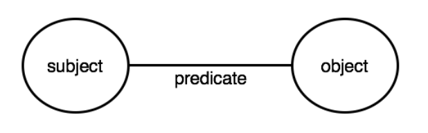

This structure is known to have two nodes (the subject and object) and an edge (the predicate).

Triples can then be linked to other triples with similarities within the subject and object.

> This means that the structure of the database is contained within the data - no need for complex database schema.

### Ethical and legal considerations of the data

**PDA Outcome 1.8. Ethical and legal considerations including data bias**

There are no ethical considerations, because it has been vetted by Public Health Scotland before being published open source. As a national health body accountable to the Scottish Government, they are duty bound to ensure that data produced cannot provide organisations or private citizens the platform to infer/publish findings that could prove detrimental to the population with intentions for defamation or self benefit.

The datasets are covered by the Open Government License, which means they can be copied, published, distributed and transmitted. The data can also be adapted and exploited commercially and non-commercially by combining it with other information or using it in applications or products.

When using this data however, acknowledgement must be made to the source of the data by linking to the source and also providing link to the Open Government Licence. Failure to do so will automatically terminate the rights to the user as stated above.